# Take-home Exercise 4

Putting Visual Analytics into Practical Use

Zhou Yiou https://example.com/zhouyiou (MITB SMU)https://example.com/spacelysprokets  
2022-02-27

## 1.0 About the task

This [take-home exercise](https://isss608-ay2021-22t2.netlify.app/th_ex/th_ex04) requires to apply appropriate data visualization techniques learned in Lesson 6 to accomplish the following tasks:

1. Script stock prices of top 40 companies in Singapore by market capitalisation between 1st January 2020 - 31st December 2021 by using *tidyquant* R package.
2. Using horizon graph to plot historical stock prices by the top 40 companies by market capitalisation.

## 2.0 Installing and loading the required libraries

In this exercise, tidyquant, tidyverse, ggplot2, dyplyr, and Knitr will be used.

- `readr` for importing csv into R.
- `tidyquant` to return objects in the tidy ‘tibble’ format and use quantitative functions together with the tidyverse functions.
- `knitr` for building static html table.
- `ggHoriPlot` for building horizon plots in ggplot2.

```r
packages = c('tidyverse', 'tidyquant', 'ggplot2','dplyr','tidyr','ggthemes','ggHoriPlot',
             'knitr')
for(p in packages){
  if(!require(p,character.only = T)){
    install.packages(p)
  }
  library(p,character.only = T)
}
```

## 3.0 data wrangling

Script data from [top 40 companies in Singapore by market capitalisation](https://companiesmarketcap.com/singapore/largest-companies-in-singapore-by-market-cap/)

Reference: [scraping of fiancial dataset](https://giniceseah.netlify.app/posts/2021-06-18-scraping-of-financial-dataset/#tidyquant-package)

#### Import the data:

```r
Companies<-read.csv('data/companiesmarketcap.csv')
```

#### Prepare the data:

Only the list of symbols was retained for the subsequent use. `slice_max()` is used to get the top 40 stocks in SGX by *marketcap*.

```r
top40<-Companies%>%
  slice_max(`marketcap`,n=40)%>%
  select(Symbol,Name)
```

#### Script data from Yahoo Finance:

```r
from_date = "2020-01-01"
to_date = "2021-12-31"
period_type = "days"  # "days"/ "weeks"/ "months"/ "years"

stock_data_daily<-top40 %>%
  tq_get(get = "stock.prices",
         from = from_date,
         to = to_date) %>%
  group_by(Symbol,Name)%>%
  select(Symbol,Name,date,close)%>%
  tq_transmute(select = NULL,
               mutate_fun = to.period,
               period  = period_type)
rmarkdown::paged_table(stock_data_daily)
```

| Symbol | Name | date | close |
| --- | --- | --- | --- |
| SE | Sea (Garena) | 2020-01-02 | 40.040001 |
| SE | Sea (Garena) | 2020-01-03 | 40.490002 |
| SE | Sea (Garena) | 2020-01-06 | 40.480000 |
| SE | Sea (Garena) | 2020-01-07 | 41.009998 |
| SE | Sea (Garena) | 2020-01-08 | 40.160000 |
| SE | Sea (Garena) | 2020-01-09 | 40.529999 |
| SE | Sea (Garena) | 2020-01-10 | 39.580002 |
| SE | Sea (Garena) | 2020-01-13 | 40.020000 |
| SE | Sea (Garena) | 2020-01-14 | 39.939999 |
| SE | Sea (Garena) | 2020-01-15 | 40.419998 |

[output cut: 9990 more lines]

## 4.0 Data Visualization

Build the horizon plots in ggplot2 using geom_horizon().

- Plot the horizon graphParse based on the dataframe *stock_data_daily*.
- `geom_horizon()` is used to plot the graph.
- `scale_fill_hcl()`is used to adjust the color scheme of graph.
- `facet_grid()`is used to parse the name variable to Y axis.

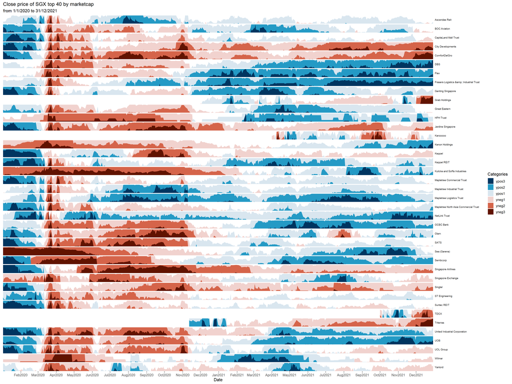

```r
stock_data_daily %>% ggplot() +
  geom_horizon(aes(date, close))+
  scale_fill_hcl(palette = 'RdBu', reverse = F) + #set the color palette
  facet_grid(Name~.) +
  theme_few() +
  theme(
    panel.spacing.y=unit(0, "lines"),
    strip.text.y = element_text(size = 7, angle = 0, hjust = 0),
    axis.text.y = element_blank(),
    axis.title.y = element_blank(),
    axis.ticks.y = element_blank(),
    panel.border = element_blank()
    ) +
  scale_x_date(expand=c(0,0),
               date_breaks = "1 month",
               date_labels = "%b%Y") +
  xlab('Date') +
  ggtitle('Close price of SGX top 40 by marketcap',
          'from 1/1/2020 to 31/12/2021')
```

Adjust the size of fond, set the x-axis interval to 2 months.

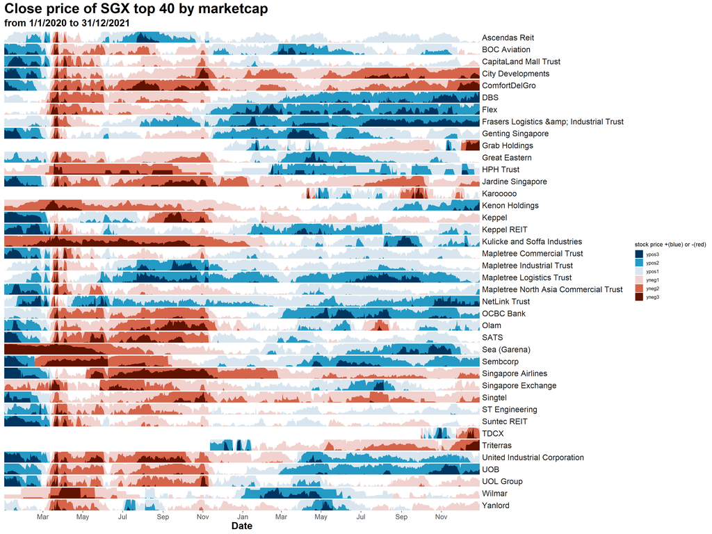

```r
stock_data_daily %>% ggplot() +
  geom_horizon(aes(date, close))+
  scale_fill_hcl(palette = 'RdBu', reverse = F) + #set the color palette
  facet_grid(Name~.) +
  theme_few() +
  theme(
    panel.spacing.y=unit(0, "lines"),
    strip.text.y = element_text(size = 16, angle = 0, hjust = 0),
    axis.text.x = element_text(size = 14),
    axis.text.y = element_blank(),
    axis.title.y = element_blank(),
    axis.ticks.y = element_blank(),
    panel.border = element_blank(),
    axis.title=element_text(size=20,face="bold"),
    plot.title = element_text(size=28, face = "bold"),
    plot.subtitle = element_text(size=20, face = "bold")
    )+
  scale_x_date(expand=c(0,0),
               date_breaks = "2 month",
               date_labels = "%b") +
  xlab('Date') +
  ggtitle('Close price of SGX top 40 by marketcap',
          'from 1/1/2020 to 31/12/2021')+
   guides(fill= guide_legend(title="stock price +(blue) or -(red)",
                       title.position = "top")
          )
```

## 5.0 Peer learning

Inspired by visualizations shown in the class, consider adopting x-axis intersection Line to highlight the timeline regarding covid-19 related events in Singapore and worldwide. To examine the impact of COVID-19 pandemic and companies’ stock price listed in the SGX.

`geom_vline()` is used to mark the time line.

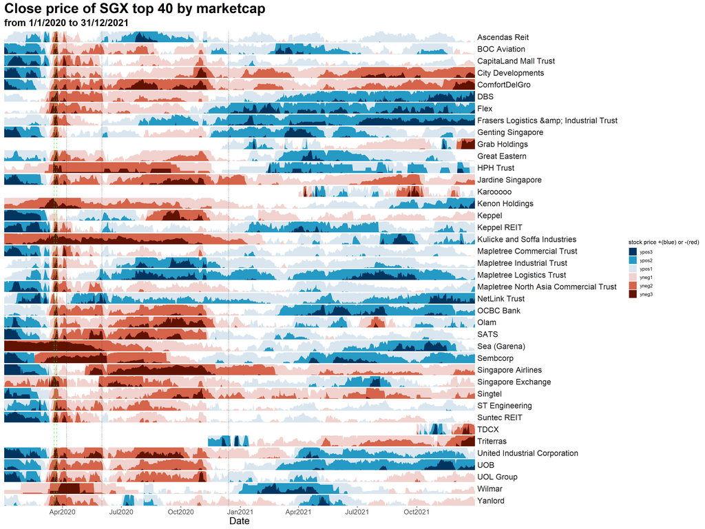

```r
stock_data_daily %>% ggplot() +
  geom_horizon(aes(date, close))+
  scale_fill_hcl(palette = 'RdBu', reverse = F) + #set the color palette
  geom_vline(xintercept = as.Date("2020-03-19"), linetype = "dotdash", color = "green", size = 0.5) +
  geom_vline(xintercept = as.Date("2020-03-23"), linetype = "dotdash", color = "green", size = 0.5) +
  geom_vline(xintercept = as.Date("2020-04-07"), linetype = "dotted", size = 0.5) +
  geom_vline(xintercept = as.Date("2020-06-01"), linetype = "dotted", size = 0.5) +
  geom_vline(xintercept = as.Date("2020-12-14"), linetype = "dotted", size = 0.5) +
  facet_grid(Name~.) +
  theme_few() +
  theme(
    panel.spacing.y=unit(0, "lines"),
    strip.text.y = element_text(size = 16, angle = 0, hjust = 0),
    axis.text.x = element_text(size = 14),
    axis.text.y = element_blank(),
    axis.title.y = element_blank(),
    axis.ticks.y = element_blank(),
    panel.border = element_blank(),
    axis.title=element_text(size=20),
    plot.title = element_text(size=28, face = "bold"),
    plot.subtitle = element_text(size=20, face = "bold")
    )+
  scale_x_date(expand=c(0,0),
               date_breaks = "3 month",
               date_labels = "%b%Y") +
  xlab('Date') +
  ggtitle('Close price of SGX top 40 by marketcap',
          'from 1/1/2020 to 31/12/2021')+
   guides(fill= guide_legend(title="stock price +(blue) or -(red)",
                       title.position = "top")
          )
```

## 6.0 Observations

The covid-19 timeline in Singapore/the world according to [straitstimes](https://www.straitstimes.com/singapore/six-months-of-covid-19-in-singapore-a-timeline):

**19 March 2020:**

- The New York Stock Exchange announced at the day that it would temporarily close its trading floor and move to all-electronic trading beginning on 23 March when two traders tested positive for COVID-19 at screenings set up by the NYSE.
- The release of the news shook the global stock market drastically, SGX was not the exception.

**23 March 2020:**

- All short-term visitors barred from entering or transiting in Singapore.
- The release of this news had a huge impact on the stock market, with almost all 40 stocks dived deep into the bottom.

**7 April 2020:**

- Circuit breaker measures kick in. Most workplaces are closed, and dining-in at eateries is not allowed.
- With the implementation of circuit breaker measures, Singapore further restricted its COVID-19 governance measures, causing a big hit to the SGX market.

**1 Jun 2020:**

- The circuit breaker lifts and Singapore enters Phase One of reopening. Parents and grandparents can receive up to two visitors at once, from the same household.
- Even With the release of good news, SGX market had very limited positive reaction. The market continued to be sluggish. Rebound seemed far away.

**14 Dec 2020:**

  From December 2020 till December 2021, even during the wave Delta and Omicron, SGX market shown a good resilience to pressure and the patter of first 6 months of 2020 has not reappeared.